# Building Energy Efficiency: Regression Analysis Framework

## 4.6 A5. Polynomial Regression

```r
poly_cl <- lm(
  CoolingLoad ~ poly(RelCompactness, 2) + poly(WallArea, 2) +
    poly(RoofArea, 2) + OverallHeight +          # linear, not poly()
    Orientation + GlazingArea + GlazingAreaDist +
    CompactnessXHeight + GlazingXCompactness,
  data = train_cl
)
```

```r
pred_poly_cl <- predict(poly_cl, newdata = test_cl)
perf_poly_cl <- eval_metrics("Polynomial", test_cl$CoolingLoad, pred_poly_cl)
print(perf_poly_cl)
```

```
## # A tibble: 1 × 4
##   Model       RMSE   MAE    R2
##   <chr>      <dbl> <dbl> <dbl>
## 1 Polynomial  2.75  2.01 0.917
```

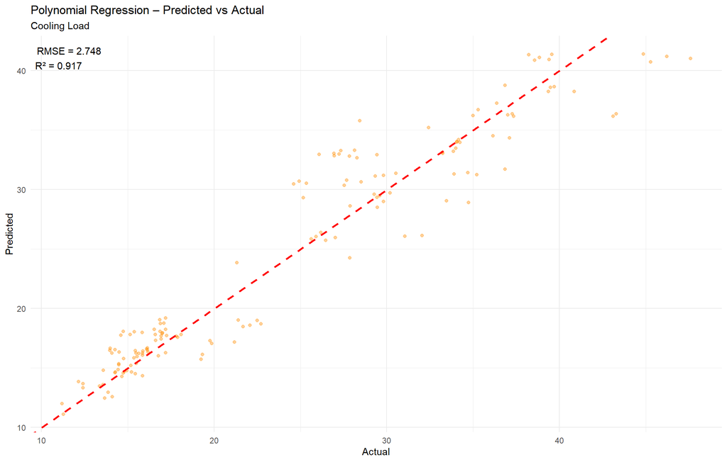

```r
ggplot(tibble(actual = test_cl$CoolingLoad, predicted = pred_poly_cl),
       aes(x = actual, y = predicted)) +
  geom_point(alpha = 0.4, color = "darkorange") +
  geom_abline(slope = 1, intercept = 0, color = "red",
              linetype = "dashed", linewidth = 1) +
  annotate("text", x = -Inf, y = Inf, hjust = -0.1, vjust = 1.5,
           label = sprintf("RMSE = %.3f\nR² = %.3f",
                           perf_poly_cl$RMSE, perf_poly_cl$R2)) +
  labs(title = "Polynomial Regression – Predicted vs Actual",
       subtitle = "Cooling Load", x = "Actual", y = "Predicted") +
  theme_minimal(base_size = 11)
```

```r
ggsave("figures/poly_pred_vs_actual_cl.png", width = 8, height = 6, dpi = 300)
```

Cooling Load: R² = 0.917 is still strong but lower and the scatter is visibly wider,especially the band of points around the 25–30 actual range that sit above the line (the model slightly over-predicts there) and the looser spread at the high end.This matches what you flagged earlier in the OLS section: cooling load is genuinely harder to model, with more variability for buildings that have higher cooling demand.

```r
poly_hl <- lm(
  HeatingLoad ~ poly(RelCompactness, 2) + poly(WallArea, 2) +
    poly(RoofArea, 2) + OverallHeight +          # linear: only 2 unique values
    Orientation + GlazingArea + GlazingAreaDist +
    CompactnessXHeight + GlazingXCompactness,
  data = train_hl
)

pred_poly_hl <- predict(poly_hl, newdata = test_hl)
perf_poly_hl <- eval_metrics("Polynomial", test_hl$HeatingLoad, pred_poly_hl)
print(perf_poly_hl)
```

```
## # A tibble: 1 × 4
##   Model       RMSE   MAE    R2
##   <chr>      <dbl> <dbl> <dbl>
## 1 Polynomial  2.41  1.73 0.943
```

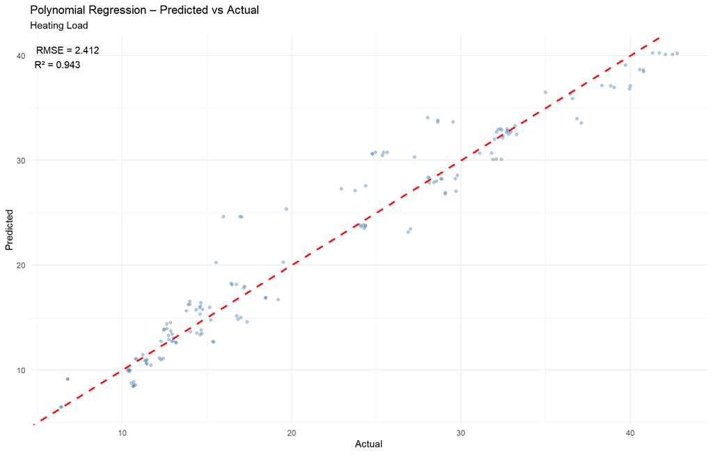

```r
ggplot(tibble(actual = test_hl$HeatingLoad, predicted = pred_poly_hl),
       aes(x = actual, y = predicted)) +
  geom_point(alpha = 0.4, color = "steelblue") +
  geom_abline(slope = 1, intercept = 0, color = "red",
              linetype = "dashed", linewidth = 1) +
  annotate("text", x = -Inf, y = Inf, hjust = -0.1, vjust = 1.5,
           label = sprintf("RMSE = %.3f\nR² = %.3f",
                           perf_poly_hl$RMSE, perf_poly_hl$R2)) +
  labs(title = "Polynomial Regression – Predicted vs Actual",
       subtitle = "Heating Load", x = "Actual", y = "Predicted") +
  theme_minimal(base_size = 11)
```

```r
ggsave("figures/poly_pred_vs_actual_hl.png", width = 8, height = 6, dpi = 300)
```

Heating Load: R² = 0.943 means the model explains about 94% of the variation in heating load, and the points hug the red line tightly across the whole range with no obvious curving away from it. The RMSE of 2.412 means typical predictions are off by roughly 2.4 units,a good fit with no systematic bias.

# 5 Part D: Model Comparison

## 5.1 D1. Performance Summary Tables

```r
results_hl <- bind_rows(
  perf_ols_hl, perf_ridge_hl, perf_lasso_hl, perf_enet_hl, perf_poly_hl
) %>%
  mutate(Response = "Heating Load") %>%
  arrange(RMSE)

results_cl <- bind_rows(
  perf_ols_cl, perf_ridge_cl, perf_lasso_cl, perf_enet_cl, perf_poly_cl
) %>%
  mutate(Response = "Cooling Load") %>%
  arrange(RMSE)

cat("===== HEATING LOAD – Model Performance (Test Set) =====\n")
```

```
## ===== HEATING LOAD – Model Performance (Test Set) =====
```

```r
print(results_hl %>% dplyr::select(Model, RMSE, MAE, R2) %>%
        mutate(across(where(is.numeric), ~round(., 4))))
```

```
## # A tibble: 5 × 4
##   Model       RMSE   MAE    R2
##   <chr>      <dbl> <dbl> <dbl>
## 1 Polynomial  2.41  1.73 0.943
## 2 ElasticNet  3.04  2.05 0.909
## 3 LASSO       3.16  2.17 0.902
## 4 OLS         3.34  2.37 0.890
## 5 Ridge       3.44  2.44 0.884
```

```r
cat("\n===== COOLING LOAD – Model Performance (Test Set) =====\n")
```

```
##
## ===== COOLING LOAD – Model Performance (Test Set) =====
```

```r
print(results_cl %>% dplyr::select(Model, RMSE, MAE, R2) %>%
        mutate(across(where(is.numeric), ~round(., 4))))
```

```
## # A tibble: 5 × 4
##   Model       RMSE   MAE    R2
##   <chr>      <dbl> <dbl> <dbl>
## 1 Polynomial  2.75  2.01 0.916
## 2 LASSO       3.10  2.08 0.894
## 3 ElasticNet  3.20  2.17 0.887
## 4 OLS         3.44  2.37 0.870
## 5 Ridge       3.48  2.48 0.866
```

## 5.2 D2. Bar Chart: RMSE Comparison

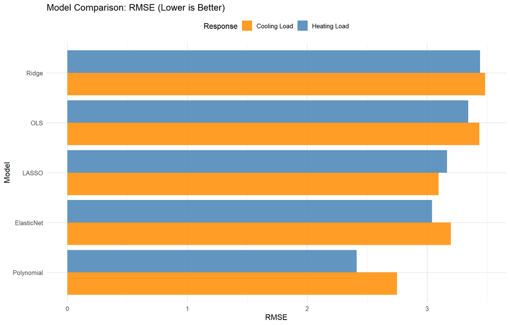

```r
all_results <- bind_rows(results_hl, results_cl)

ggplot(all_results, aes(x = reorder(Model, RMSE), y = RMSE, fill = Response)) +
  geom_col(position = "dodge", alpha = 0.85) +
  coord_flip() +
  scale_fill_manual(values = c("Heating Load" = "steelblue",
                               "Cooling Load"  = "darkorange")) +
  labs(title  = "Model Comparison: RMSE (Lower is Better)",
       x = "Model", y = "RMSE") +
  theme_minimal(base_size = 12) +
  theme(legend.position = "top")
```

```r
ggsave("figures/model_comparison_rmse.png", width = 9, height = 6, dpi = 300)
```

## 5.3 D3. Bar Chart: R² Comparison

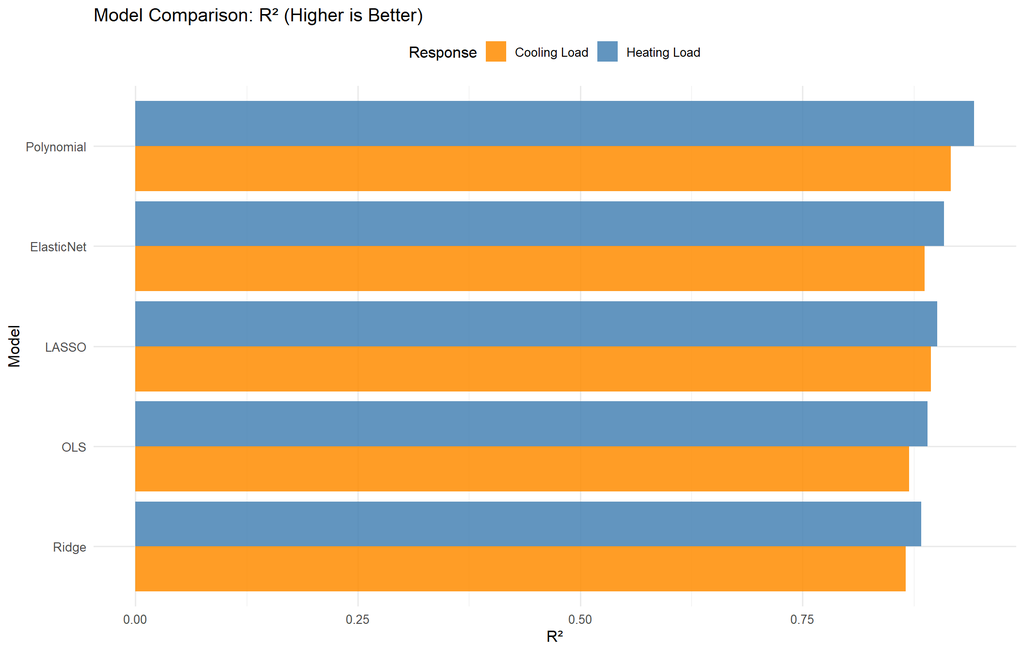

```r
ggplot(all_results, aes(x = reorder(Model, R2), y = R2, fill = Response)) +
  geom_col(position = "dodge", alpha = 0.85) +
  coord_flip() +
  scale_fill_manual(values = c("Heating Load" = "steelblue",
                               "Cooling Load"  = "darkorange")) +
  labs(title  = "Model Comparison: R² (Higher is Better)",
       x = "Model", y = "R²") +
  theme_minimal(base_size = 12) +
  theme(legend.position = "top")
```

```r
ggsave("figures/model_comparison_r2.png", width = 9, height = 6, dpi = 300)
```

## 5.4 D4. Predicted vs Actual — Best Models

```r
# Identify best model per response by R²
best_hl_name <- results_hl %>% slice_max(R2, n = 1) %>% pull(Model)
best_cl_name <- results_cl %>% slice_max(R2, n = 1) %>% pull(Model)
cat("Best model (HL):", best_hl_name, "\n")
```

```
## Best model (HL): Polynomial
```

```r
cat("Best model (CL):", best_cl_name, "\n")
```

```
## Best model (CL): Polynomial
```

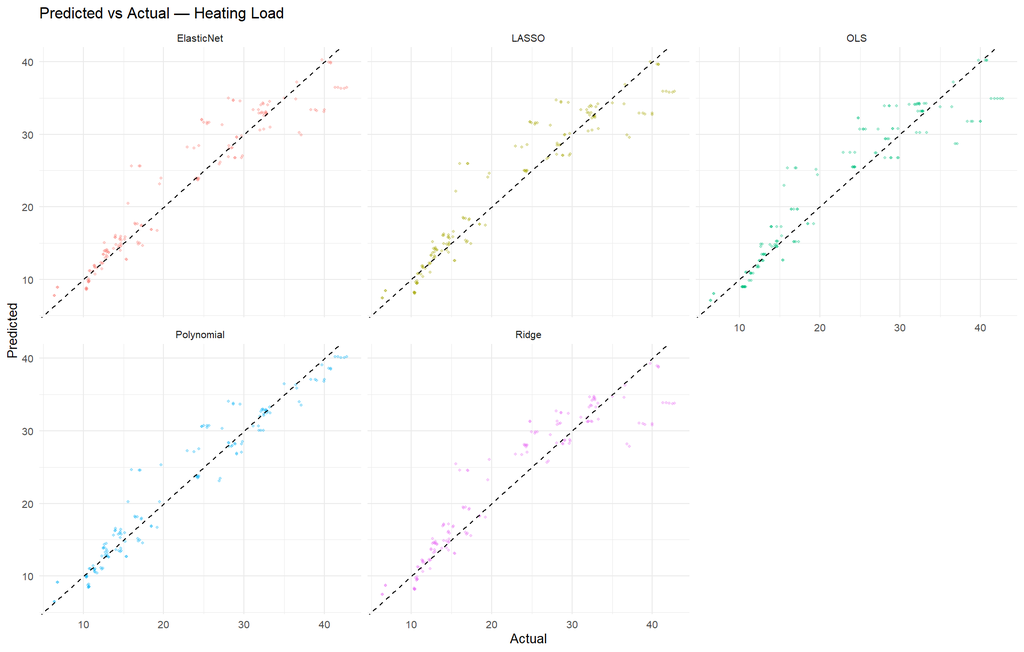

```r
# Predictions from all candidates — compiled for plotting
preds_hl <- tibble(
  Actual     = test_hl$HeatingLoad,
  OLS        = pred_ols_hl,
  Ridge      = as.vector(pred_ridge_hl),
  LASSO      = as.vector(pred_lasso_hl),
  ElasticNet = as.vector(pred_enet_hl),
  Polynomial = pred_poly_hl
) %>% pivot_longer(-Actual, names_to = "Model", values_to = "Predicted")

ggplot(preds_hl, aes(x = Actual, y = Predicted, color = Model)) +
  geom_point(alpha = 0.3, size = 0.8) +
  geom_abline(slope = 1, intercept = 0, linetype = "dashed", color = "black") +
  facet_wrap(~Model, ncol = 3) +
  labs(title = "Predicted vs Actual — Heating Load", x = "Actual", y = "Predicted") +
  theme_minimal(base_size = 10) +
  theme(legend.position = "none")
```

```r
ggsave("figures/pred_vs_actual_hl.png", width = 9, height = 6, dpi = 300)
```

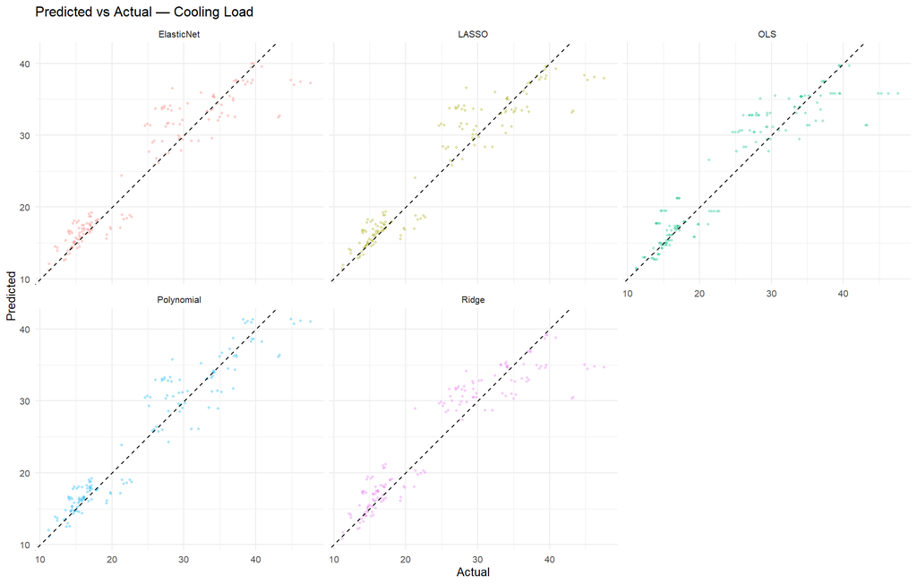

```r
preds_cl <- tibble(
  Actual     = test_cl$CoolingLoad,
  OLS        = pred_ols_cl,
  Ridge      = as.vector(pred_ridge_cl),
  LASSO      = as.vector(pred_lasso_cl),
  ElasticNet = as.vector(pred_enet_cl),
  Polynomial = pred_poly_cl
) %>% pivot_longer(-Actual, names_to = "Model", values_to = "Predicted")

ggplot(preds_cl, aes(x = Actual, y = Predicted, color = Model)) +
  geom_point(alpha = 0.3, size = 0.8) +
  geom_abline(slope = 1, intercept = 0, linetype = "dashed", color = "black") +
  facet_wrap(~Model, ncol = 3) +
  labs(title = "Predicted vs Actual — Cooling Load", x = "Actual", y = "Predicted") +
  theme_minimal(base_size = 10) +
  theme(legend.position = "none")
```

```r
ggsave("figures/pred_vs_actual_cl.png", width = 9, height = 6, dpi = 300)
```

# 6 Part E: Feature Importance Synthesis

## 6.1 E1. OLS Coefficient Plot

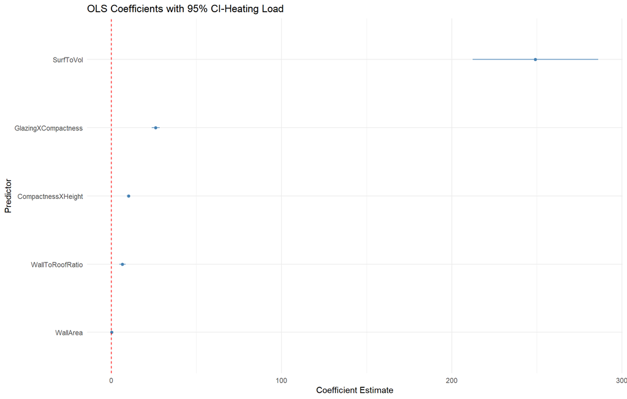

```r
coef_df <- broom::tidy(ols_hl, conf.int = TRUE) %>%
  filter(term != "(Intercept)")

ggplot(coef_df, aes(x = reorder(term, estimate), y = estimate,
                    ymin = conf.low, ymax = conf.high)) +
  geom_pointrange(color = "steelblue", fatten = 2) +
  geom_hline(yintercept = 0, color = "red", linetype = "dashed") +
  coord_flip() +
  labs(title = "OLS Coefficients with 95% CI-Heating Load",
       x = "Predictor", y = "Coefficient Estimate") +
  theme_minimal()
```

```r
ggsave("figures/ols_coefficients_hl.png", width = 8, height = 6, dpi = 300)
```

# 7 Part F: Residual Analysis — Best Models

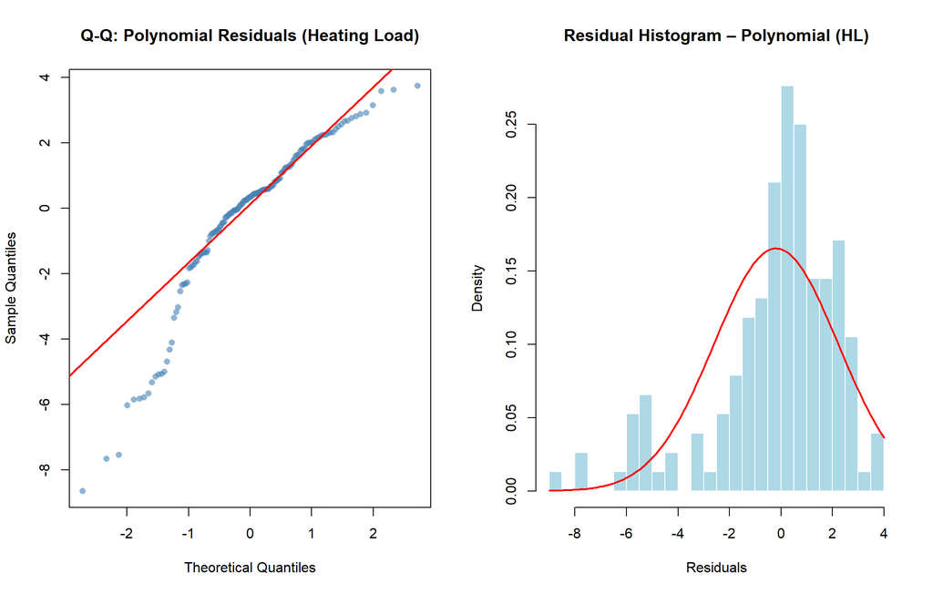

```r
# Residuals for the best parametric model (Polynomial regression)
resid_poly_hl <- test_hl$HeatingLoad - pred_poly_hl

par(mfrow = c(1, 2))
qqnorm(resid_poly_hl, main = "Q-Q: Polynomial Residuals (Heating Load)",
       col = adjustcolor("steelblue", 0.6), pch = 16)
qqline(resid_poly_hl, col = "red", lwd = 2)

hist(resid_poly_hl, breaks = 30, col = "lightblue", border = "white",
     main = "Residual Histogram – Polynomial (HL)",
     xlab = "Residuals", probability = TRUE)
curve(dnorm(x, mean(resid_poly_hl), sd(resid_poly_hl)),
      add = TRUE, col = "red", lwd = 2)
```

```r
dev.print(png, "figures/residuals_poly_hl.png", width = 1100, height = 550, res = 120)
```

```r
par(mfrow = c(1, 1))
```

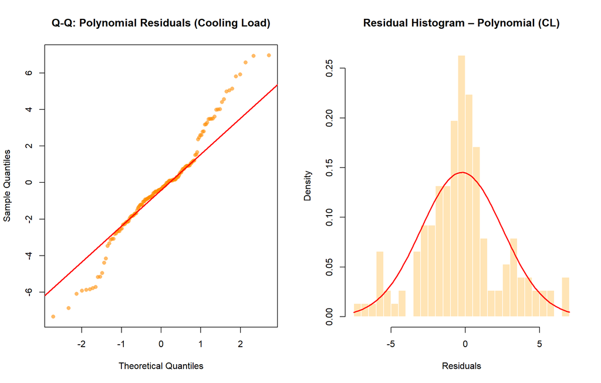

```r
resid_poly_cl <- test_cl$CoolingLoad - pred_poly_cl

par(mfrow = c(1, 2))
qqnorm(resid_poly_cl, main = "Q-Q: Polynomial Residuals (Cooling Load)",
       col = adjustcolor("darkorange", 0.6), pch = 16)
qqline(resid_poly_cl, col = "red", lwd = 2)

hist(resid_poly_cl, breaks = 30, col = "moccasin", border = "white",
     main = "Residual Histogram – Polynomial (CL)",
     xlab = "Residuals", probability = TRUE)
curve(dnorm(x, mean(resid_poly_cl), sd(resid_poly_cl)),
      add = TRUE, col = "red", lwd = 2)
```

```r
dev.print(png, "figures/residuals_poly_cl.png", width = 1100, height = 550, res = 120)
```

```r
par(mfrow = c(1, 1))
```